# 2022 Rating Curves

Jake Cavaiani, Karen Jorgenson

11/7/2022

The purpose of this script is to read in pressure transducer data from 2022 and generate rating curves to ultimately generate predicted continuous discharge records throughout the whole season.

Read in most updated merged files from each site from the google drive (DoD Project->2022 AK sensors->Discharge->site->“merged_date_file” )

### ALL Sites

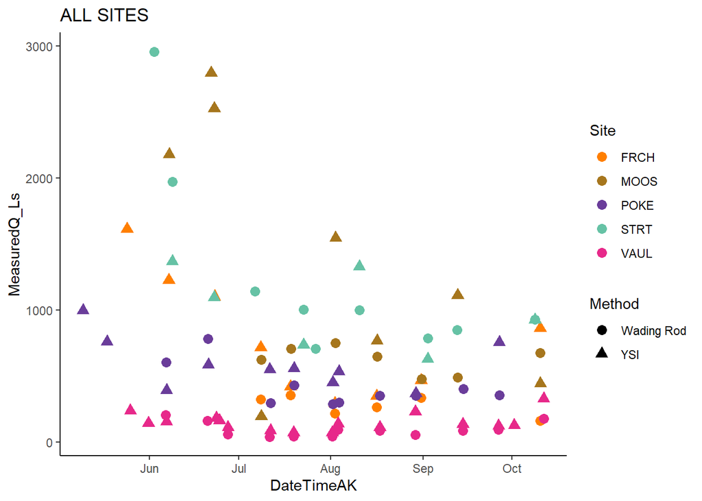

```r
# Import data from google drive #
discharge.2022 <- "https://docs.google.com/spreadsheets/d/e/2PACX-1vQR6HHHDpnxc6DmNHfdNLR9-dgDHR5Imt0Ve4_t2DzIF18_8D3O2da5zcWQzJUSoFQfaetPZDeXZ610/pub?gid=0&single=true&output=csv"
QSummary.2022 <- read.csv(url(discharge.2022))

### Format Time ###
QSummary.2022$Date <- mdy(QSummary.2022$Date)
QSummary.2022$DateTimeAK <- as.POSIXct(paste(QSummary.2022$Date, QSummary.2022$Time), format = "%Y-%m-%d %H:%M", tz = "America/Anchorage")
QSummary.2022$DateTimeAK <- lubridate::round_date(QSummary.2022$DateTimeAK, "60 minutes")

### ALL Sites ###
QSummary.2022 %>% ggplot() +
  geom_point(aes(x=DateTimeAK, y=MeasuredQ_Ls, color=Site, shape=Method), size=3) +
  theme_classic() +
  scale_color_manual(values=c("#FF7F00","#A6761D", "#6A3D9A", "#66C2A5", "#E7298A")) + ggtitle("ALL SITES")
```

Here is all the discrete discharge measurements for 2022

Eielson atmospheric pressure data will be used to fill gaps in air pressure.

```r
eielson.atmo.2022.url <- "https://docs.google.com/spreadsheets/d/e/2PACX-1vQjJbkVdOseFUsTFMDXaHRoKkPiFt6Uvc-9R3tkFZxKFjqSmPPgZzexdbhezBr_qYgGUdVN6ywYR28c/pub?output=csv"

eielson.atmo.2022 <- read.csv(url(eielson.atmo.2022.url), skip = 6)
eielson.atmo.2022 <- eielson.atmo.2022[-1,]

names(eielson.atmo.2022) <- c("Site", "DateTimeAK", "sea_level_pressure", "AirPressure")

eielson.atmo.2022$DateTimeAK <- mdy_hm(eielson.atmo.2022$DateTimeAK)

# Correct time zone
eielson.atmo.2022$DateTimeAK <- eielson.atmo.2022$DateTimeAK - 28800
eielson.atmo.2022$DateTimeAK <- force_tz(eielson.atmo.2022$DateTimeAK, tzone = "America/Anchorage")
#attributes(eielson.atmo.2022$DateTimeAK)$tzone <- "America/Anchorage"

eielson.atmo.2022$DateTimeAK <- lubridate::round_date(eielson.atmo.2022$DateTimeAK, "15 minutes")

eielson.atmo.2022$AirPressure <- as.numeric(eielson.atmo.2022$AirPressure)
eielson.atmo.2022$sea_level_pressure <- as.numeric(eielson.atmo.2022$sea_level_pressure)

# Take average at 15 min interval
eielson.atmo.2022 <- eielson.atmo.2022 %>% group_by(DateTimeAK) %>% summarise(DateTimeAK = unique(DateTimeAK), AirPressure = mean(AirPressure),
      sea_level_pressure = mean(sea_level_pressure))


eielson.atmo.2022$AirPressure <- eielson.atmo.2022$AirPressure*3.38639 # converting from inHG to kPa

## conversion to elevation at each site
# MOOS elevation is 574 feet
# POKE 760.96 ft
# STRT 820 ft
# FRCH 601 ft
# VAUL 688.8 ft

eielson.atmo.2022.compare <- eielson.atmo.2022
eielson.atmo.2022.compare$mmHG <- eielson.atmo.2022.compare$sea_level_pressure * 25.44 # converting to mmHG


# MOOS
eielson.atmo.2022.compare$mmHGcorrectedMOOS <- eielson.atmo.2022.compare$mmHG - (2.5*574/100)
eielson.atmo.2022.compare$AirPressureCorrectedMOOS <- eielson.atmo.2022.compare$mmHGcorrectedMOOS * 0.133322 # converting this to kPA to compare with MOOS PT

# POKE
eielson.atmo.2022.compare$mmHGcorrectedPOKE <- eielson.atmo.2022.compare$mmHG - (2.5*760.96/100)
eielson.atmo.2022.compare$AirPressureCorrectedPOKE <- eielson.atmo.2022.compare$mmHGcorrectedPOKE * 0.133322 # converting this to kPA

# STRT
eielson.atmo.2022.compare$mmHGcorrectedSTRT <- eielson.atmo.2022.compare$mmHG - (2.5*820/100)
eielson.atmo.2022.compare$AirPressureCorrectedSTRT <- eielson.atmo.2022.compare$mmHGcorrectedSTRT * 0.133322 # converting this to kPA

# FRCH
eielson.atmo.2022.compare$mmHGcorrectedFRCH <- eielson.atmo.2022.compare$mmHG - (2.5*601/100)
eielson.atmo.2022.compare$AirPressureCorrectedFRCH <- eielson.atmo.2022.compare$mmHGcorrectedFRCH * 0.133322 # converting this to kPA

# VAUL
eielson.atmo.2022.compare$mmHGcorrectedVAUL <- eielson.atmo.2022.compare$mmHG - (2.5*688.8/100)
eielson.atmo.2022.compare$AirPressureCorrectedVAUL <- eielson.atmo.2022.compare$mmHGcorrectedVAUL * 0.133322 # converting this to kPA
```

### MOOS

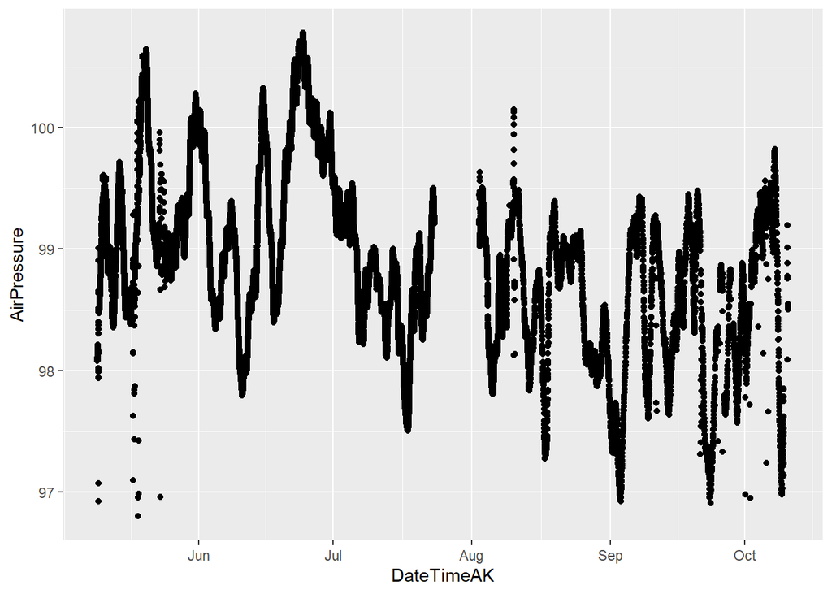

```r
# Load in water pressure data
# urls
moos.atmo.2022.url <- "https://docs.google.com/spreadsheets/d/e/2PACX-1vQ7QMNWjVX1R43qflIW7lVqkj7wRHouhgQhWK76kfR8zK-UZg9bFSm92ccPy8T0luhFHKwsLNQQjA56/pub?output=csv"
moos.stream.one.2022.url <- "https://docs.google.com/spreadsheets/d/e/2PACX-1vRo04g32Yr3DsZbXQiw6VTPfgWuWq5csh1VhxfMy3IT3U6OkJOGvTlofjXwFfugiaRVJ34pPnOUZ3te/pub?output=csv"
moos.stream.two.2022.url <- "https://docs.google.com/spreadsheets/d/e/2PACX-1vQRXmAtoP_7I2RYEDZrdCT1LDyD8W3Thjst549srxdlWDMUYUyBjiGABd8pgtZE9Efa8b4Vgb3qtyoc/pub?output=csv"

# load in data
moos.atmo.2022 <- read.csv(url(moos.atmo.2022.url), skip = 1)
moos.stream.one.2022 <- read.csv(url(moos.stream.one.2022.url), skip = 1)
moos.stream.two.2022 <- read.csv(url(moos.stream.two.2022.url), skip = 1)

# cleaning df to be able to interpret and merge
moos.atmo.2022 <- moos.atmo.2022[, -c(5:11)] # removing columns that aren't date/abs pressure and temp
moos.stream.one.2022 <- moos.stream.one.2022[, -c(5:13)] # removing columns that aren't date/abs pressure and temp
moos.stream.two.2022 <- moos.stream.two.2022[, -c(5:13)] # removing columns that arent date/abs pressure and temp

# changing datetime to AK time
moos.atmo.2022$DateTimeAK <- mdy_hms(moos.atmo.2022$Date.Time..GMT.08.00)

moos.stream.one.2022$DateTimeAK <- mdy_hms(moos.stream.one.2022$Date.Time..GMT.08.00)

moos.stream.two.2022$DateTimeAK <- mdy_hms(moos.stream.two.2022$Date.Time..GMT.08.00)

moos.stream.two.2022$DateTimeAK <- force_tz(moos.stream.two.2022$DateTimeAK, tzone = "America/Anchorage")

moos.stream.one.2022$DateTimeAK <- force_tz(moos.stream.one.2022$DateTimeAK, tzone = "America/Anchorage")

moos.atmo.2022$DateTimeAK <- force_tz(moos.atmo.2022$DateTimeAK, tzone = "America/Anchorage")

# round date to 5 minute intervals
moos.atmo.2022$DateTimeAK <- lubridate::round_date(moos.atmo.2022$DateTimeAK, "5 minutes")
moos.stream.one.2022$DateTimeAK <- lubridate::round_date(moos.stream.one.2022$DateTimeAK, "5 minutes")
moos.stream.two.2022$DateTimeAK <- lubridate::round_date(moos.stream.two.2022$DateTimeAK, "5 minutes")

# changing the names

# cleaning off original datetime
moos.atmo.2022 <- moos.atmo.2022[, -c(2)] # removing columns that aren't date/abs pressure and temp
moos.stream.one.2022 <- moos.stream.one.2022[, -c(2)] # removing columns that aren't date/abs pressure and temp
moos.stream.two.2022 <- moos.stream.two.2022[, -c(2)] # removing columns that arent

names(moos.atmo.2022) <- c("Site", "AirPressure", "TempC", "DateTimeAK")

names(moos.stream.one.2022) <- c("Site", "WaterPressure", "TempC", "DateTimeAK")

names(moos.stream.two.2022) <- c("Site", "WaterPressure", "TempC",  "DateTimeAK")

moos.atmo.2022 %>% filter(AirPressure > 96.8) %>% ggplot(aes(x = DateTimeAK, y = AirPressure)) +
  geom_point()
```

This is the raw atmospheric pressure that is located at MOOS. I am going to clean this up a little bit:

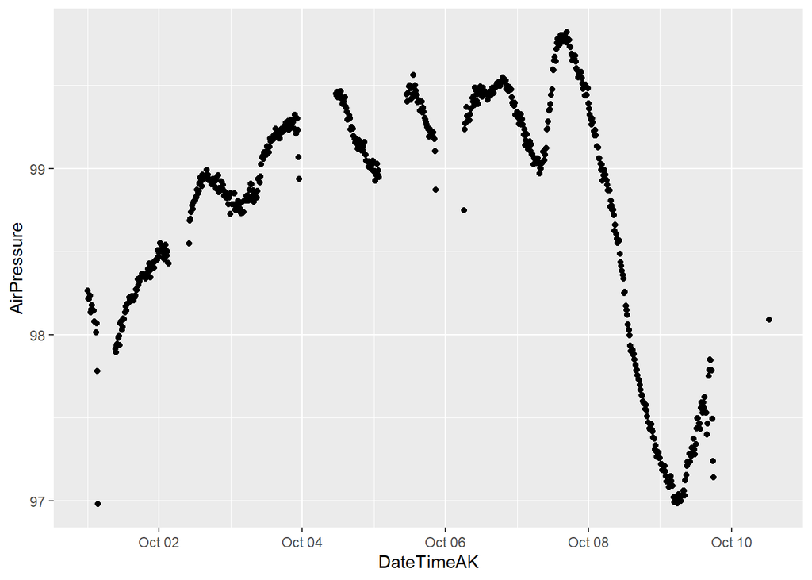

```r
# cleaning erroneous points
moos.atmo.2022 <- moos.atmo.2022 %>%
  mutate(across(c(AirPressure),
                ~ifelse(DateTimeAK <= "2022-06-01" & AirPressure < 97.5, NA, .))) %>% filter(AirPressure > 96.5)

moos.atmo.2022 <- moos.atmo.2022 %>%
  mutate(across(c(AirPressure),
                ~ifelse(DateTimeAK >= "2022-05-15" & DateTimeAK <= "2022-05-20" & AirPressure < 98.2, NA, .)))

moos.atmo.2022 <- moos.atmo.2022 %>%
  mutate(across(c(AirPressure),
                ~ifelse(DateTimeAK >= "2022-05-18" & DateTimeAK <= "2022-05-20" & AirPressure < 99.1, NA, .)))

moos.atmo.2022 <- moos.atmo.2022 %>%
  mutate(across(c(AirPressure),
                ~ifelse(DateTimeAK >= "2022-08-10" & DateTimeAK <= "2022-08-12" & AirPressure > 99.5, NA, .)))

moos.atmo.2022 <- moos.atmo.2022 %>%
  mutate(across(c(AirPressure),
                ~ifelse(DateTimeAK >= "2022-08-10" & DateTimeAK <= "2022-08-12" & AirPressure < 99, NA, .)))

moos.atmo.2022 <- moos.atmo.2022 %>%
  mutate(across(c(AirPressure),
                ~ifelse(DateTimeAK >= "2022-08-10" & AirPressure < 96.8, NA, .)))

moos.atmo.2022 <- moos.atmo.2022 %>% filter(DateTimeAK <= "2022-10-10 12:30:00") %>% mutate(across(c(AirPressure),
                ~ifelse(DateTimeAK >= "2022-10-3"& DateTimeAK <= "2022-10-8" & AirPressure < 98.5, NA, .)))

moos.atmo.2022 <- moos.atmo.2022 %>% mutate(across(c(AirPressure),
                ~ifelse(DateTimeAK >= "2022-10-2"& DateTimeAK <= "2022-10-3" & AirPressure < 98, NA, .)))


moos.atmo.2022 %>% filter(DateTimeAK <= "2022-10-15" & DateTimeAK >= "2022-10-01") %>% ggplot(aes(x = DateTimeAK, y = AirPressure)) +
  geom_point()
```

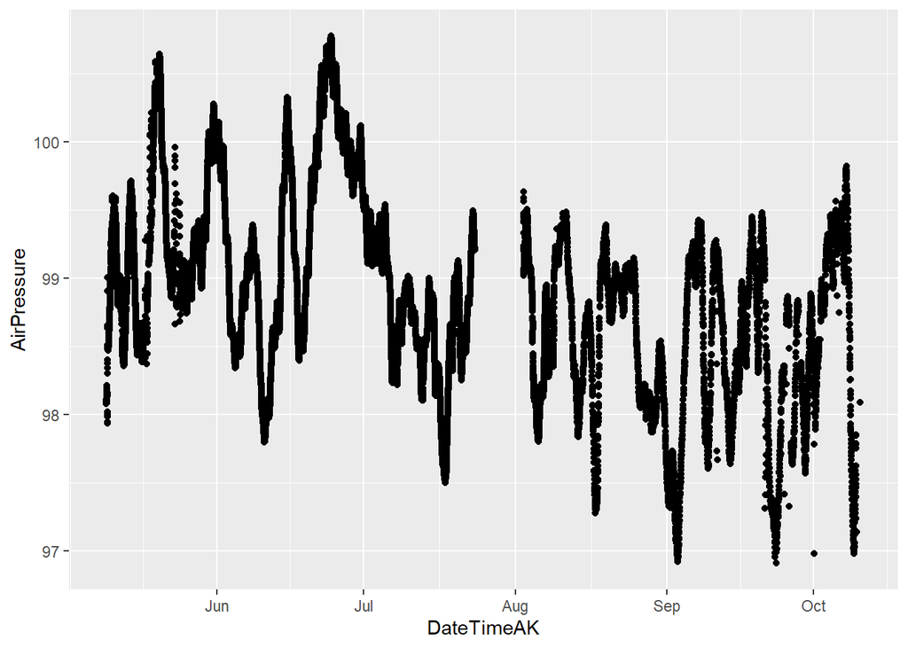

```r
moos.atmo.2022 %>% ggplot(aes(x = DateTimeAK, y = AirPressure)) +
  geom_point()
```

This is a little better.

Here is the uncorrected air pressure comparison between Eielson and MOOS:

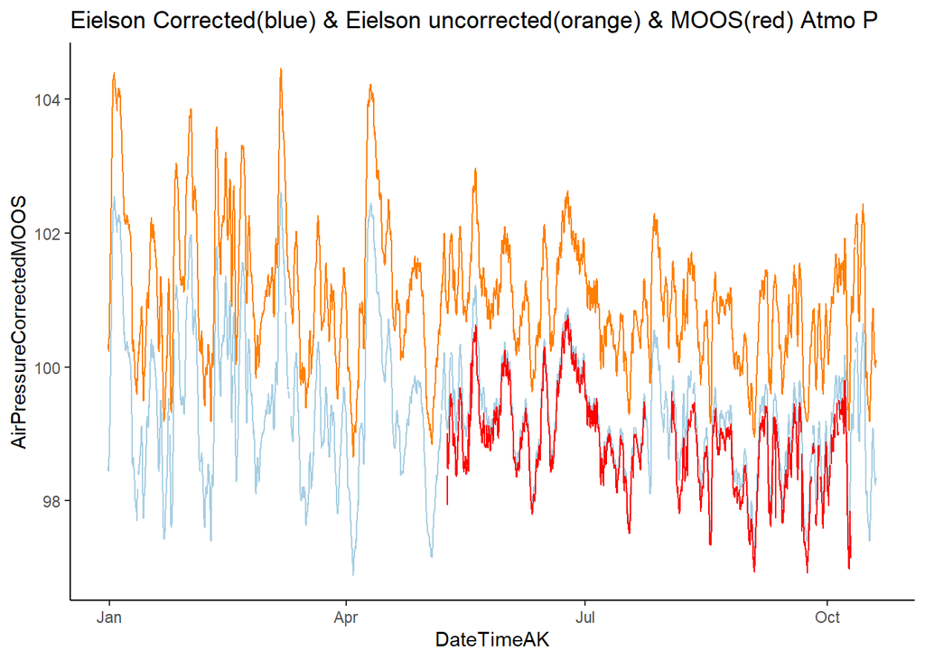

```r
moos.atmo.2022.compare <- moos.atmo.2022

atmo.pt.2022.1 <- left_join(eielson.atmo.2022.compare, moos.atmo.2022.compare, by = "DateTimeAK")

atmo.pt.2022.1 %>% #filter(DateTimeAK >= "2022-05-01" & DateTimeAK <= "2022-05-15") %>%
  ggplot(aes(x = DateTimeAK, y = AirPressureCorrectedMOOS)) +
  geom_line(aes(x=DateTimeAK, y=AirPressureCorrectedMOOS), color="#A6CEE3") +
  geom_line(aes(x=DateTimeAK, y=AirPressure.x), color="#FF7F00") +
  geom_line(aes(x=DateTimeAK, y=AirPressure.y), color = "red") +
  theme_classic() +
  ggtitle("Eielson Corrected(blue) & Eielson uncorrected(orange) & MOOS(red) Atmo P")
```

Looks like we have to use the corrected pressure to get what we want for our rating curves.

We will only use pressure transducer 2 at Moose because it is more complete.

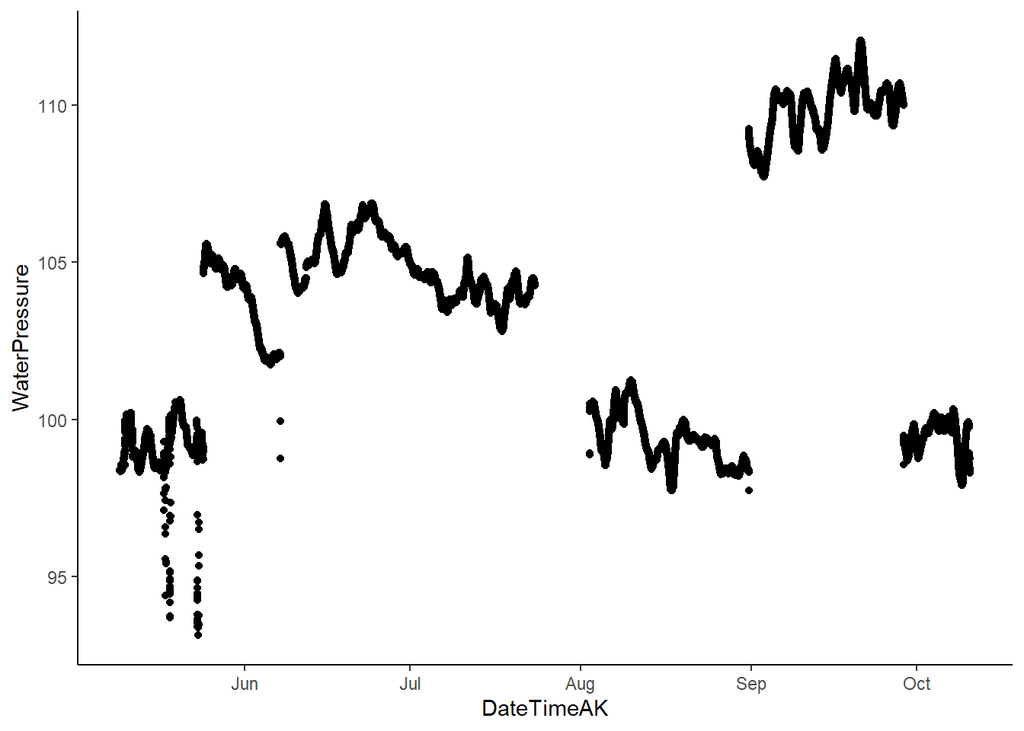

```r
ggplot(moos.stream.two.2022, aes(x = DateTimeAK, y = WaterPressure)) +
  geom_point() +
  theme_classic()
```

This is PT2 that has the step changes due to the cleaning and then it has a gap at the end of July to beginning of August was because the memory filled up.

```r
# adjusting/cleaning moos.stream.two
#moos.stream.two.2022.b <- moos.stream.two.2022
#moos.stream.two.2022 <- moos.stream.two.2022.b

moos.stream.two.2022 <- moos.stream.two.2022 %>%
  mutate(across(c(WaterPressure),
                ~ifelse(DateTimeAK <= "2022-05-25", NA, .))) # PT wasnt placed into the stream until 5/25

moos.stream.two.2022 <- moos.stream.two.2022 %>%
  mutate(across(c(WaterPressure),
                ~ifelse(DateTimeAK >= "2022-06-01" & DateTimeAK <= "2022-07-01" & WaterPressure < 101, NA, .))) %>% filter(WaterPressure > 90)

# shifting the step change
moos.2.before <- moos.stream.two.2022[c(1:3913), ] # 6/7 @ 14:05 we cleaned the PVC housing so we are shifting the previous data up to match after the cleaning
moos.2.after <- moos.stream.two.2022[c(3914:40000), ]
moos.stream.two.2022[3914, 2] - moos.stream.two.2022[3913, 2] # 3.573
```

```
## [1] 3.573
```

```r
moos.2.before$WaterPressure <- moos.2.before[, 2] + 3.573
moos.stream.two.2022 <- full_join(moos.2.before, moos.2.after)

moos.2.before2 <- moos.stream.two.2022[c(1:25525), ]
moos.2.mid2 <- moos.stream.two.2022[c(25531:33593), ]
moos.2.after2 <- moos.stream.two.2022[c(33593:40000), ]
moos.stream.two.2022[25525, 2] - moos.stream.two.2022[25531, 2]  # 10.918
```

```
## [1] -10.918
```

```r
moos.2.mid2$WaterPressure <- moos.2.mid2[, 2] - 10.918
moos.stream.two.2022.2 <- full_join(moos.2.before2, moos.2.mid2)
moos.stream.two.2022 <- full_join(moos.stream.two.2022.2, moos.2.after2)

## Bring the last chunk up half way?
moos.stream.two.2022 <- moos.stream.two.2022 %>%
  mutate(across(c(WaterPressure),
                ~ifelse(DateTimeAK > "2022-08-01", WaterPressure + 3.897/2, .)))
#moos.2.before3 <- moos.stream.two.2022[c(1:17192), ]
#moos.2.after3 <- moos.stream.two.2022[c(17193:40000), ]
moos.stream.two.2022[17192, 2] - moos.stream.two.2022[17211, 2] # 3.897
```

```
## [1] 1.9485
```

```r
#moos.2.after3$WaterPressure <- moos.2.after3[, 2] + 5.389/2
#moos.stream.two.2022 <- full_join(moos.2.before3, moos.2.after3)

moos.stream.two.2022 <- moos.stream.two.2022 %>% filter(DateTimeAK < "2022-07-31" | DateTimeAK > "2022-08-02 16:45:00") %>% filter(DateTimeAK <= "2022-10-08 08:15:00")

# shifting small step change
moos.2.before4 <- moos.stream.two.2022[c(1:5240), ]
moos.2.after4 <- moos.stream.two.2022[c(5241:40000), ]
moos.stream.two.2022[5240, 2] - moos.stream.two.2022[5241, 2] # 0.365
```

```
## [1] -0.365
```

```r
moos.2.after4$WaterPressure <- moos.2.after4[, 2] - 0.365
moos.stream.two.2022 <- full_join(moos.2.before4, moos.2.after4)

# shifting small step change
moos.2.before5 <- moos.stream.two.2022[c(1:33588), ]
moos.2.after5 <- moos.stream.two.2022[c(33591:40000), ]
moos.stream.two.2022[33588, 2] - moos.stream.two.2022[33591, 2] # 0.41
```

```
## [1] -0.009
```

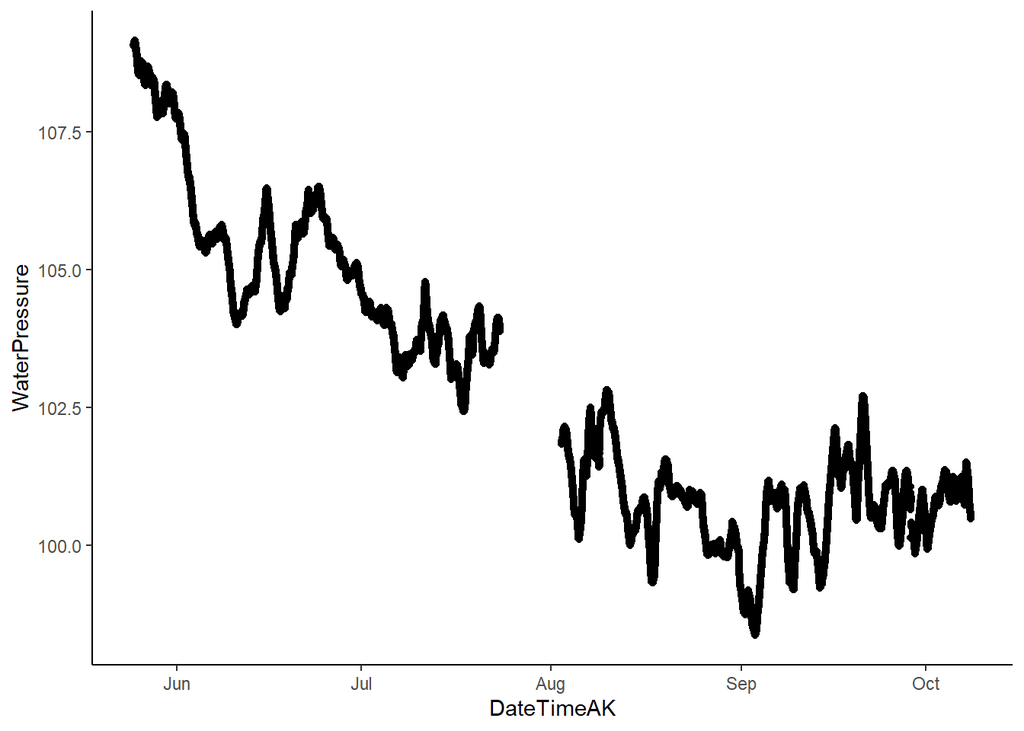

```r
moos.2.after5$WaterPressure <- moos.2.after5[, 2] - 0.41
moos.stream.two.2022 <- full_join(moos.2.before5, moos.2.after5)

moos.stream.two.2022 <- moos.stream.two.2022 %>% filter(WaterPressure < 110)

moos.stream.two.2022 %>%
  #filter(DateTimeAK > "2022-09-28 12:00:00" & DateTimeAK < "2022-09-29") %>%
  ggplot(aes(x = DateTimeAK, y = WaterPressure)) +
  geom_point() +
  theme_classic()
```

This looks much better

```r
## Combine water and air pressure
# Final water pressure
moos.final.pressure.2022 <- moos.stream.two.2022


moos.final.pressure.2022 <- moos.final.pressure.2022[,-c(3,5,7)] # removing columns that are unnecessary. I only need both water pressures and mean pressure with a DateTime column


eielson.atmo.2022 <- eielson.atmo.2022[,-c(1,3)] # i dont need site, Temp and sea_level_pressure column

eielson.atmo.2022.compare <-  eielson.atmo.2022.compare[ , -which(names(eielson.atmo.2022.compare) %in% c("Site","TempC", "sea_level_pressure", "AirPressure", "mmHG", "mmHGcorrectedMOOS","mmHGcorrectedPOKE","mmHGcorrectedSTRT","mmHGcorrectedFRCH","mmHGcorrectedVAUL"))] # removing columns I do not need

# Fill gap during end of July for our pressure data with Eielson data
atmo.pt.2022.1$moos.combo <- ifelse(atmo.pt.2022.1$DateTimeAK > "2022-07-23 17:15:00" & atmo.pt.2022.1$DateTimeAK < "2022-08-02 17:00:00", atmo.pt.2022.1$AirPressureCorrectedMOOS, atmo.pt.2022.1$AirPressure.y)

# Remove outliers
atmo.pt.2022.1 <- atmo.pt.2022.1 %>%
  mutate(across(c(moos.combo),
                ~ifelse(DateTimeAK >= "2022-09-10" & DateTimeAK <= "2022-09-11" & moos.combo < 98.5, NA, .)))

#atmo.pt.2022.1 %>% filter(DateTimeAK > "2022-05-15") %>%
  #filter(DateTimeAK > "2022-06-01" & DateTimeAK < "2022-09-01") %>%
 # ggplot(aes(DateTimeAK, AirPressureCorrectedMOOS)) + geom_point() #+ geom_vline(xintercept = as.POSIXct("2022-09-10")) + geom_vline(xintercept = as.POSIXct("2022-09-12"))
```

Our Moose air pressure data is so messy - it is probably more accurate to use Eielson’s data.

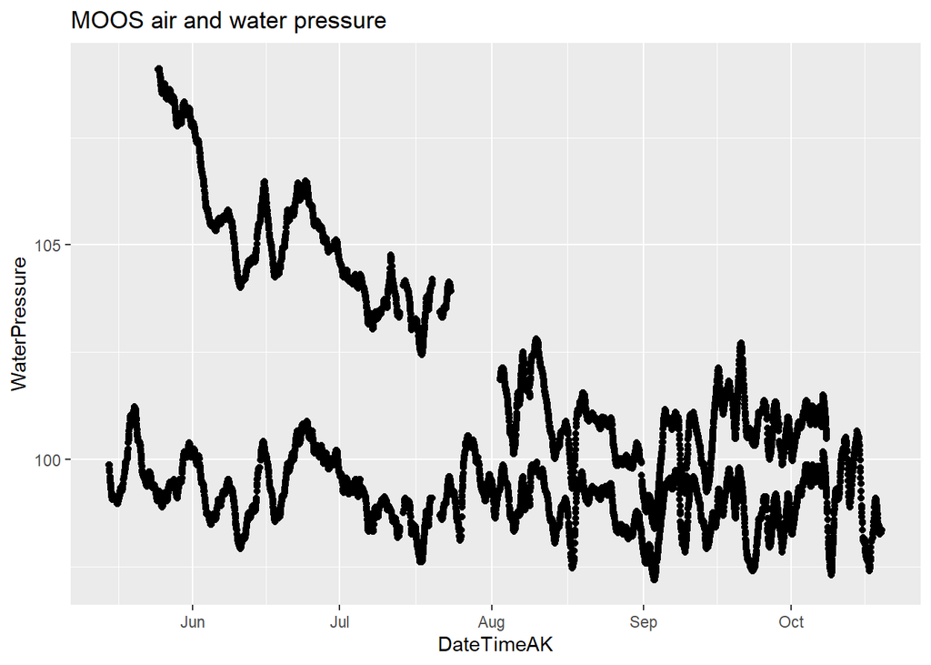

```r
#join the atmospheric and water pressure together

MOOS.2022 <- left_join(atmo.pt.2022.1, moos.final.pressure.2022, by = "DateTimeAK")


# Water pressure - atmospheric pressure
 MOOS.2022$difference <- MOOS.2022$WaterPressure - MOOS.2022$AirPressureCorrectedMOOS



 MOOS.2022 %>% filter(DateTimeAK > "2022-05-15") %>%
  #filter(DateTimeAK > "2022-09-18" & DateTimeAK < "2022-09-22") %>%
  ggplot(aes(DateTimeAK, WaterPressure)) + geom_point() + geom_point(aes(DateTimeAK, AirPressureCorrectedMOOS)) + #geom_vline (xintercept = as.POSIXct("2022-09-20 20:00:00"))
ggtitle("MOOS air and water pressure")
```

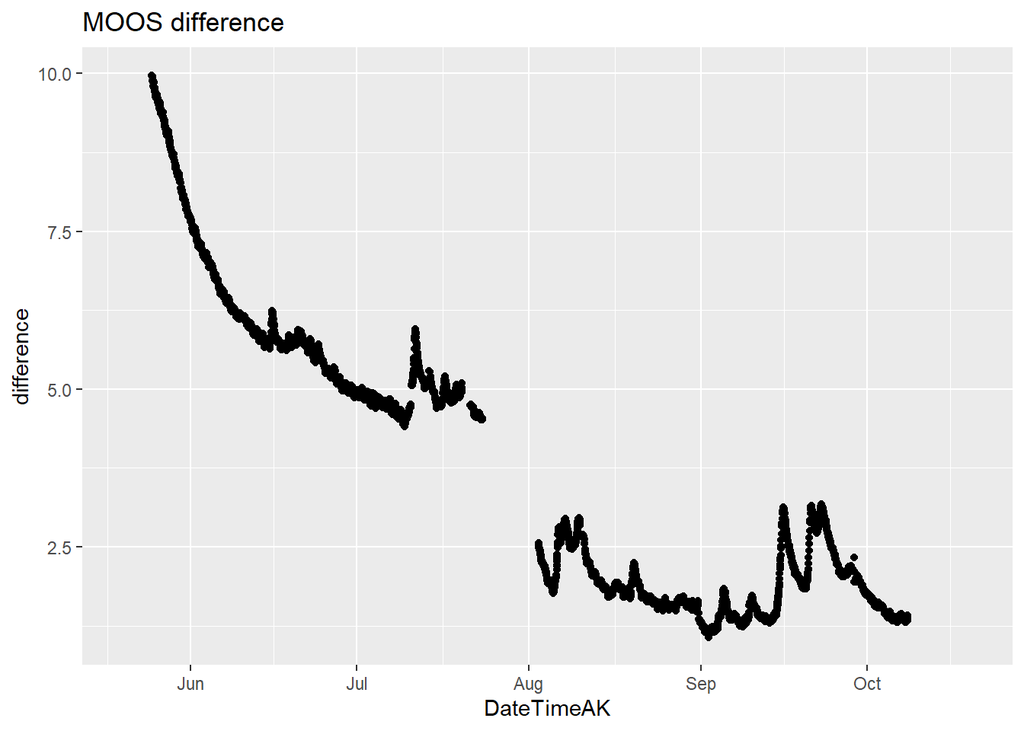

```r
# Plot difference
MOOS.2022 %>% filter(DateTimeAK > "2022-05-20") %>%
  ggplot(aes(DateTimeAK, difference)) + geom_point() +
  ggtitle("MOOS difference")
```

```r
#MOOS.2022 %>% filter(DateTimeAK > "2022-09-01" & DateTimeAK < "2022-10-15") %>% filter(difference > 5) %>% View()
```

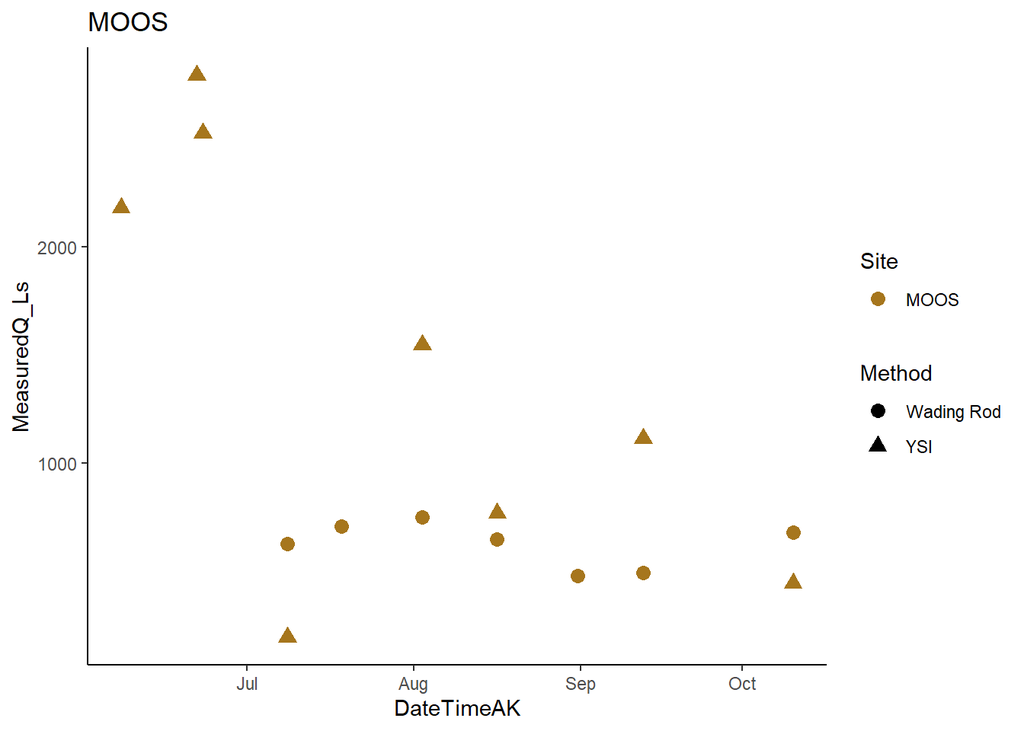

```r
### Plot MOOS measured Q
QSummary.MO.2022 <- QSummary.2022 %>% filter(Site =="MOOS")

ggplot(QSummary.MO.2022) +
  geom_point(aes(x = DateTimeAK, y = MeasuredQ_Ls, shape = Method, color = Site), size=3) +
  theme_classic() +
  scale_color_manual(values=c("#A6761D")) +
  ggtitle("MOOS")
```

```r
# trying to merge by nearest date if we have an offset point
MOOS.2022.dt <- setDT(MOOS.2022)
MOOS.2022.dt <- subset(MOOS.2022.dt, DateTimeAK < "2022-10-19 14:00:00") %>% na.omit()# removing rows that had dates corresponding to end of record that messed up the rolling nearest function
QSummary.MO.2022.dt <- QSummary.MO.2022

Moose1comb.2022 <- MOOS.2022.dt[QSummary.MO.2022.dt, on = "DateTimeAK", roll = 'nearest']

## ONLY using PT 2
MOOS1.lm.2022 <- lm(Moose1comb.2022$MeasuredQ_Ls ~ Moose1comb.2022$difference)
#summary(MOOS1.lm.2022)
```

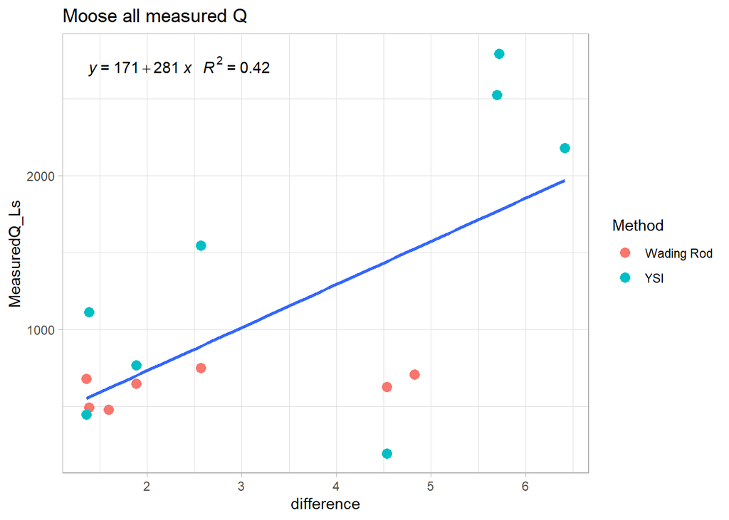

```r
# plot rating curve
moos.formula = y~x

ggplot(aes(x = difference, y = MeasuredQ_Ls), data = Moose1comb.2022) +
  geom_point(aes(color = Method), size = 3) +
  geom_smooth(method = "lm", se=FALSE, formula = moos.formula) +
  stat_poly_eq(formula = moos.formula,
               aes(label = paste(..eq.label.., ..rr.label.., sep = "~~~")),
               parse = TRUE) +
  theme_light() +
  ggtitle("Moose all measured Q")
```

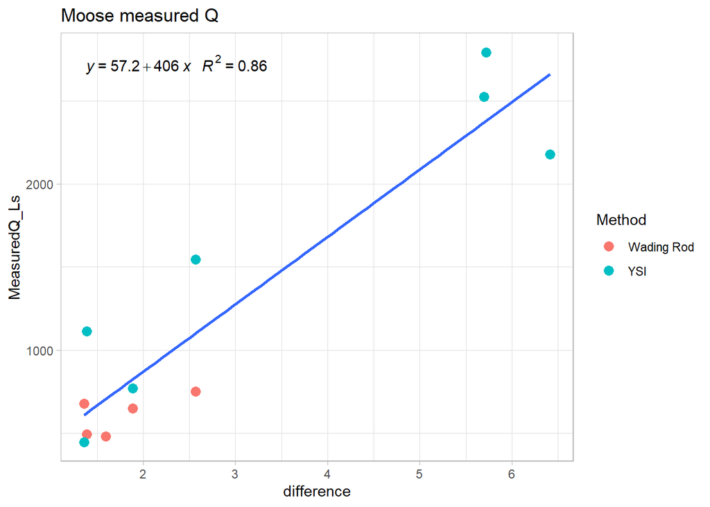

```r
# Remove outlier Q points
Moose1comb.2022.2 <- Moose1comb.2022 %>% filter(difference < 4 | MeasuredQ_Ls > 1000)

# plot rating curve
moos.formula = y~x

ggplot(aes(x = difference, y = MeasuredQ_Ls), data = Moose1comb.2022.2) +
  geom_point(aes(color = Method), size = 3) +
  geom_smooth(method = "lm", se=FALSE, formula = moos.formula) +
  stat_poly_eq(formula = moos.formula,
               aes(label = paste(..eq.label.., ..rr.label.., sep = "~~~")),
               parse = TRUE) +
  theme_light() +
  ggtitle("Moose measured Q")
```

I will try removing the two low difference, high measured Q points

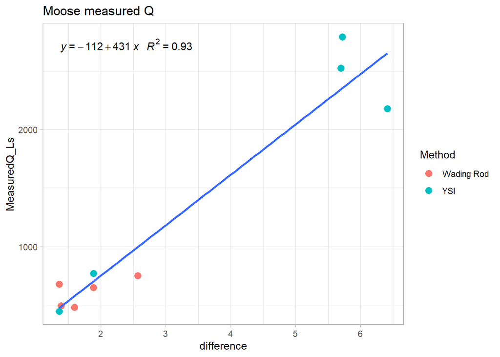

```r
# Remove two low difference, high measured Q points
Moose1comb.2022.3 <- Moose1comb.2022.2 %>% filter(MeasuredQ_Ls < 1000 | MeasuredQ_Ls > 2000)

# plot rating curve
moos.formula = y~x

ggplot(aes(x = difference, y = MeasuredQ_Ls), data = Moose1comb.2022.3) +
  geom_point(aes(color = Method), size = 3) +
  geom_smooth(method = "lm", se=FALSE, formula = moos.formula) +
  stat_poly_eq(formula = moos.formula,
               aes(label = paste(..eq.label.., ..rr.label.., sep = "~~~")),
               parse = TRUE) +
  theme_light() +
  ggtitle("Moose measured Q")
```

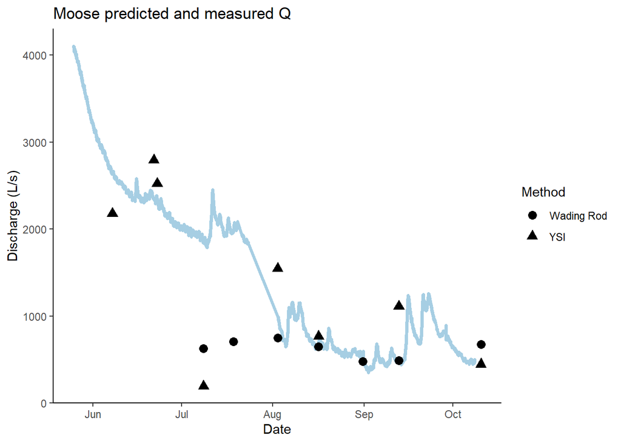

```r
## Predict MOOS Q

MOOS1.lm.2022 <- lm(Moose1comb.2022.3$MeasuredQ_Ls ~ Moose1comb.2022.3$difference)

MOOS.2022.dt$pred.moos1.Q <- coef(MOOS1.lm.2022)[2] * MOOS.2022.dt$difference+ coef(MOOS1.lm.2022)[1]

MOOS.2022.dt <- MOOS.2022.dt %>% select(DateTimeAK, pred.moos1.Q) %>% filter(DateTimeAK >= "2022-05-25 08:05:00" & DateTimeAK <= "2022-10-08 16:15:00")
MOOS.2022.dt <- na_kalman(MOOS.2022.dt)

MOOS.2022.dt %>% na.omit() %>% ggplot(aes(x = DateTimeAK, y = pred.moos1.Q)) +
  geom_line(color="#A6CEE3", size=1.25) +
  geom_point(data = Moose1comb.2022, aes(x = DateTimeAK, y = MeasuredQ_Ls, shape = Method), size=3) +
  theme_classic() +
  ggtitle("Moose predicted and measured Q") +
  xlab("Date") +
  ylab("Discharge (L/s)")
```

### POKE

```r
poke.stream.one.2022.url <- "https://docs.google.com/spreadsheets/d/e/2PACX-1vR8p1pdbkQBMo54XaZinGwxyzojCnlkXeZid3EFvmt9v31PFvpsa1DlWClj8aG0kkJIuU57WXl-cq7Q/pub?output=csv"
poke.stream.two.2022.url <- "https://docs.google.com/spreadsheets/d/e/2PACX-1vR-wJjf3rO8eC7bMpQZgwqFLHFQpf5qCInyWtUF1PqaCB8Z_EoM1cTHRUmWypjftREIx1rP0V6zYJxL/pub?output=csv"

# load in url
poke.stream.one.2022 <- read.csv(url(poke.stream.one.2022.url), skip = 1)
poke.stream.two.2022 <- read.csv(url(poke.stream.two.2022.url), skip = 1)

# cleaning df to be able to interpret and merge
poke.stream.one.2022 <- poke.stream.one.2022[, -c(5:18)] # removing columns that arent date/abs pressure and temp

poke.stream.two.2022 <- poke.stream.two.2022[, -c(5:9)] # removing columns that arent date/abs pressure and temp

# changing to AK time (It reads in as GMT but it is actually AKST )
poke.stream.one.2022$DateTimeAK <- mdy_hms(poke.stream.one.2022$Date.Time..GMT.08.00)

poke.stream.two.2022$DateTimeAK <- mdy_hms(poke.stream.two.2022$Date.Time..GMT.08.00)

poke.stream.two.2022$DateTimeAK <- force_tz(poke.stream.two.2022$DateTimeAK, tzone = "America/Anchorage")

poke.stream.one.2022$DateTimeAK <- force_tz(poke.stream.one.2022$DateTimeAK, tzone = "America/Anchorage")

# round date to 5 minute intervals
poke.stream.one.2022$DateTimeAK <- lubridate::round_date(poke.stream.one.2022$DateTimeAK, "5 minutes")
poke.stream.two.2022$DateTimeAK <- lubridate::round_date(poke.stream.two.2022$DateTimeAK, "5 minutes")

# cleaning off original datetime
poke.stream.one.2022 <- poke.stream.one.2022[, -c(2)] # removing columns that aren't date/abs pressure and temp
poke.stream.two.2022 <- poke.stream.two.2022[, -c(2)] # removing columns that arent


names(poke.stream.one.2022) <- c("Site", "WaterPressure", "TempC", "DateTimeAK")
names(poke.stream.two.2022) <- c("Site", "WaterPressure", "TempC", "DateTimeAK")
```

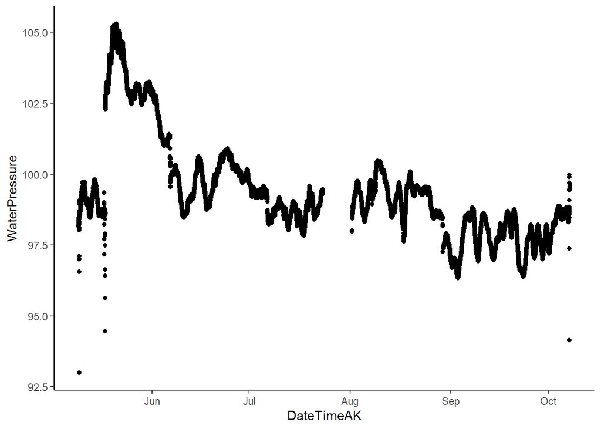

```r
ggplot(poke.stream.one.2022, aes(x = DateTimeAK, y = WaterPressure))+
  geom_point() +
  theme_classic()
```

This is PT1….step change is air pressure and then placed in the stream. Let me clip that out

```r
#poke.stream.one.2022.b <- poke.stream.one.2022
#poke.stream.one.2022 <- poke.stream.one.2022.b

#adjusting/cleaning poke.stream.one
poke.stream.one.2022 <- poke.stream.one.2022 %>%
  mutate(across(c(WaterPressure),
                ~ifelse(DateTimeAK >= "2022-05-09" & DateTimeAK <= "2022-05-18", NA, .))) # PT wasnt placed into the stream until 5/17

poke.stream.one.2022 <- poke.stream.one.2022 %>%
  mutate(across(c(WaterPressure),
                ~ifelse(DateTimeAK >= "2022-08-27" & DateTimeAK <= "2022-08-31" & WaterPressure < 98.3, NA, .))) %>% filter( DateTimeAK <= "2022-10-07 15:30:00")

poke.stream.one.2022 <- poke.stream.one.2022 %>%
  mutate(across(c(WaterPressure),
                ~ifelse(DateTimeAK >= "2022-10-05" & DateTimeAK <= "2022-10-07" & WaterPressure < 98, NA, .)))

poke.stream.one.2022 <- poke.stream.one.2022 %>%
  mutate(across(c(WaterPressure),
                ~ifelse(DateTimeAK >= "2022-10-05" & DateTimeAK <= "2022-10-07" & WaterPressure < 98, NA, .))) %>%
  filter(DateTimeAK > "2022-08-01 16:15:00" | DateTimeAK < "2022-08-01 00:00:00") %>%
  filter(DateTimeAK != "2022-08-07 19:00:00")

# shifting small step change
poke.2.before <- poke.stream.one.2022[c(1:16756), ]
poke.2.after <- poke.stream.one.2022[c(16758:40000), ]
poke.stream.one.2022[16756, 2] - poke.stream.one.2022[16758, 2] # 0.39
```

```
## [1] 0.39
```

```r
poke.2.after$WaterPressure <- poke.2.after[, 2] + 0.39
poke.stream.one.2022 <- full_join(poke.2.before, poke.2.after)

# shifting larger step change
poke.1.before2 <- poke.stream.one.2022[c(1:8125), ]
poke.1.after2 <- poke.stream.one.2022[c(8150:40000), ]
poke.stream.one.2022[8150, 2] - poke.stream.one.2022[8125, 2] # 1.55
```

```
## [1] -1.55
```

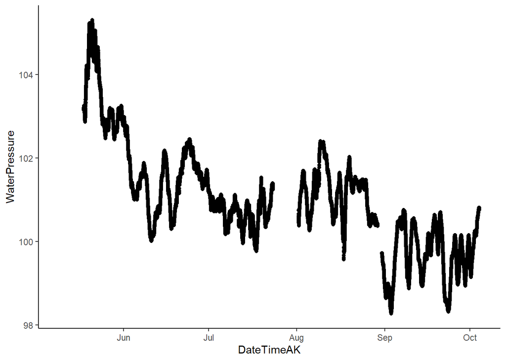

```r
poke.1.after2$WaterPressure <- poke.1.after2[, 2] + 1.55
poke.stream.one.2022 <- full_join(poke.1.before2, poke.1.after2)


poke.stream.one.2022 %>% #filter(DateTimeAK > "2022-08-07" & DateTimeAK < "2022-08-15") %>%
  ggplot(aes(x = DateTimeAK, y = WaterPressure))+
  geom_point() +
  theme_classic()
```

Clean PT2

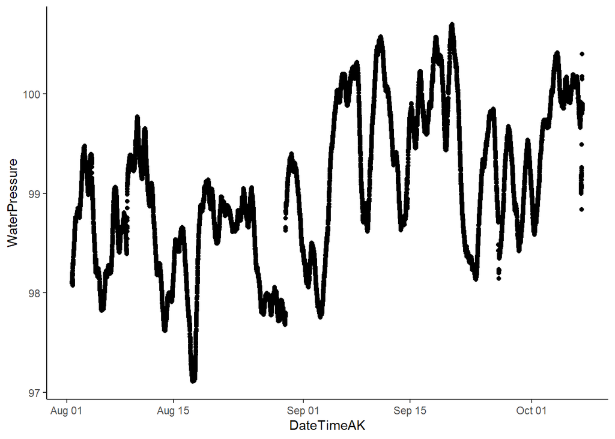

```r
poke.stream.two.2022 <- poke.stream.two.2022 %>%
  mutate(across(c(WaterPressure),
                ~ifelse(DateTimeAK >= "2022-09-17" & WaterPressure < 98, NA, .))) %>%
  filter(DateTimeAK <= "2022-10-07 15:35:00")

poke.stream.two.2022 %>% ggplot(aes(x = DateTimeAK, y = WaterPressure))+
  geom_point() +
  theme_classic()
```

This is PT2…we only have data from 8/1 because of our musical chairs situation. We got two PTs back from onset so we deployed a second PT at POKE.

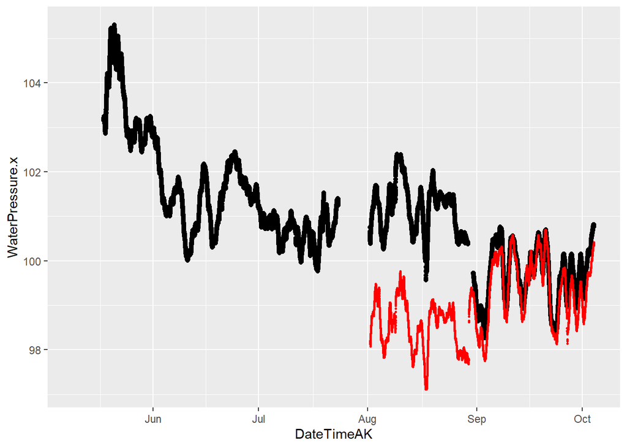

```r
# merge to one
poke.final.pressure.2022 <- left_join(poke.stream.one.2022, poke.stream.two.2022, by = c("DateTimeAK"))
poke.final.pressure.2022$MeanPressure <- rowMeans(poke.final.pressure.2022[,c(2,6)], na.rm = TRUE)

poke.final.pressure.2022 %>% ggplot() + geom_point(aes(DateTimeAK, WaterPressure.x)) + geom_point(aes(DateTimeAK, WaterPressure.y), color = "red", cex = 0.5)
```

It looks like we should use PT1 before August 1st (black) and PT2 after August 1st (red).

```r
## Use PT1 before August 1st and PT2 after August 1st
# Shift PT2 up to match August PT1
poke.final.pressure.2022 %>% filter(DateTimeAK > "2022-08-01" & DateTimeAK < "2022-08-15") %>% summarise(mean(WaterPressure.x - WaterPressure.y)) #2.62398
```

| mean(WaterPressure.x - WaterPressure.y) |
| --- |
| 2.614106 |